# OECD CPI Analysis and Forecasting - Import and Clean

2018-10-12

In this post I’ll look at the steps to import, clean and begin modelling a real world dataset exploring longitudinal Consumer Price Index changes for OECD countries. This data has been pulled from [Kaggle](https://www.kaggle.com/oecd-org/oecd-consumer-price-index-of-all-items). For this exercise, we’ll look at the CPI changes across Australia, New Zealand, United States and Canada.

Our data is sitting in a unique csv file for each country. We’ll start slow by inspecting the shape of the data and construct a method for pulling/cleaning this information to suit our needs.

```r
## Import to AUS object from csv
AUS <- read_csv("C:/Users/squin/Desktop/Blog/Data/consumer-price-index-of-all-items-in-australia.csv")
## Parsed with column specification:
## cols(
##   realtime_end = col_date(format = ""),
##   value = col_character(),
##   realtime_start = col_date(format = ""),
##   date = col_date(format = "")
## )
# Check strucure
str(AUS)
```

```
## Classes 'tbl_df', 'tbl' and 'data.frame':    254 obs. of  4 variables:
##  $ realtime_end  : Date, format: "2018-10-11" "2018-10-11" ...
##  $ value         : chr  "." "." "." "." ...
##  $ realtime_start: Date, format: "2018-10-11" "2018-10-11" ...
##  $ date          : Date, format: "1955-01-01" "1955-04-01" ...
##  - attr(*, "spec")=List of 2
##   ..$ cols   :List of 4
##   .. ..$ realtime_end  :List of 1
##   .. .. ..$ format: chr ""
##   .. .. ..- attr(*, "class")= chr  "collector_date" "collector"
##   .. ..$ value         : list()
##   .. .. ..- attr(*, "class")= chr  "collector_character" "collector"
##   .. ..$ realtime_start:List of 1
##   .. .. ..$ format: chr ""
##   .. .. ..- attr(*, "class")= chr  "collector_date" "collector"
##   .. ..$ date          :List of 1
##   .. .. ..$ format: chr ""
##   .. .. ..- attr(*, "class")= chr  "collector_date" "collector"
##   ..$ default: list()
##   .. ..- attr(*, "class")= chr  "collector_guess" "collector"
##   ..- attr(*, "class")= chr "col_spec"
```

Our value column is listed as a character, so we’ll look at that more closely before converting to a number.

```r
# List unique values, check for inappropriate strings
unique(AUS$value)
```

```
##   [1] "."                "7.80437044745057" "7.90842872008324"
##   [4] "8.01248699271592" "8.1165452653486"  "8.22060353798127"
##   [7] "8.32466181061394" "8.42872008324662" "8.53277835587929"
##  [10] "8.63683662851197" "8.74089490114464" "8.84495317377731"
##  [13] "8.94901144640999" "9.05306971904266" "9.15712799167534"
##  [16] "9.26118626430801" "9.36524453694068" "9.46930280957336"
##  [19] "9.57336108220604" "9.78147762747138" "9.88553590010406"
##  [22] "9.98959417273673" "10.0936524453694" "10.1977107180021"
##  [25] "10.4058272632674" "10.5098855359001" "10.6139438085328"
##  [28] "10.9261186264308" "11.1342351716961" "11.2382934443288"
##  [31] "11.3423517169615" "11.5504682622268" "11.6545265348595"
##  [34] "11.8626430801249" "12.2788761706556" "12.6951092611863"
##  [37] "13.111342351717"  "13.5275754422477" "14.047866805411"
##  [40] "14.7762747138398" "15.2965660770031" "15.9209157127992"
##  [43] "16.4412070759625" "16.5452653485952" "17.4817898022893"
```

[output cut: 54 more lines]

Looks like the import converted the numeric values to strings, we’ll convert them to numeric as “Value” (note case sensitivity here).

```r
#  Set up a new column with converted Values
AUS$Value <- as.double(AUS$value)
# Check new column
unique(AUS$Value)
```

```
##   [1]         NA   7.804370   7.908429   8.012487   8.116545   8.220604
##   [7]   8.324662   8.428720   8.532778   8.636837   8.740895   8.844953
##  [13]   8.949011   9.053070   9.157128   9.261186   9.365245   9.469303
##  [19]   9.573361   9.781478   9.885536   9.989594  10.093652  10.197711
##  [25]  10.405827  10.509886  10.613944  10.926119  11.134235  11.238293
##  [31]  11.342352  11.550468  11.654527  11.862643  12.278876  12.695109
##  [37]  13.111342  13.527575  14.047867  14.776275  15.296566  15.920916
##  [43]  16.441207  16.545265  17.481790  18.002081  18.418314  18.834547
##  [49]  19.979188  20.395421  20.915713  21.331946  21.852237  22.164412
##  [55]  22.580645  22.996878  23.517170  23.933403  24.557752  25.182102
##  [61]  25.910510  26.430801  27.263267  27.679501  28.303850  28.928200
##  [67]  29.552549  30.176899  31.425598  32.049948  32.778356  33.922997
##  [73]  34.963580  35.691988  36.420395  37.044745  37.981270  37.773153
##  [79]  37.877211  38.397503  38.917794  39.438085  40.374610  41.311134
##  [85]  42.143600  43.080125  43.808533  44.953174  46.201873  47.138398
```

[output cut: 20 more lines]

```r
tail(AUS)
```

```
## # A tibble: 6 x 5
##   realtime_end value            realtime_start date       Value
##   <date>       <chr>            <date>         <date>     <dbl>
## 1 2018-10-11   114.984391259105 2018-10-11     2017-01-01  115.
## 2 2018-10-11   115.19250780437  2018-10-11     2017-04-01  115.
## 3 2018-10-11   115.920915712799 2018-10-11     2017-07-01  116.
## 4 2018-10-11   116.649323621228 2018-10-11     2017-10-01  117.
## 5 2018-10-11   117.169614984391 2018-10-11     2018-01-01  117.
## 6 2018-10-11   117.585848074922 2018-10-11     2018-04-01  118.
```

Values are showing as dbl data, so we’ll go ahead and plot the data.

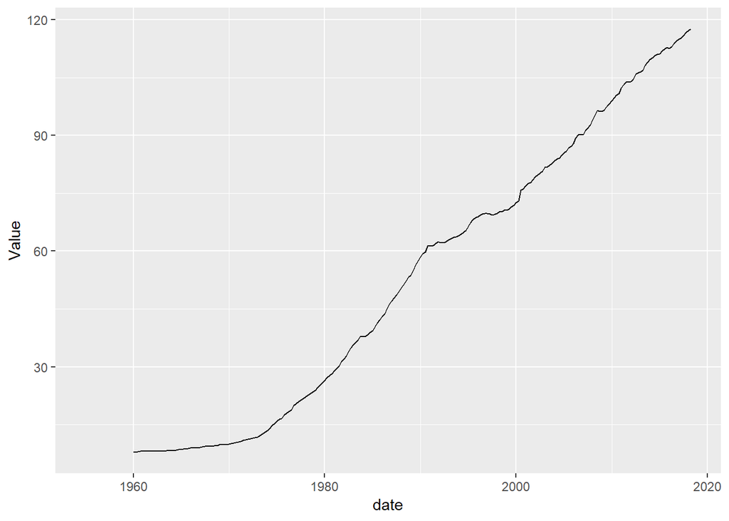

```r
ggplot(AUS, aes(x = date, y = Value)) + geom_line()
```

Looks good! We can shorthand this process by piping the code through. We’ll try this with our next file which is canada.

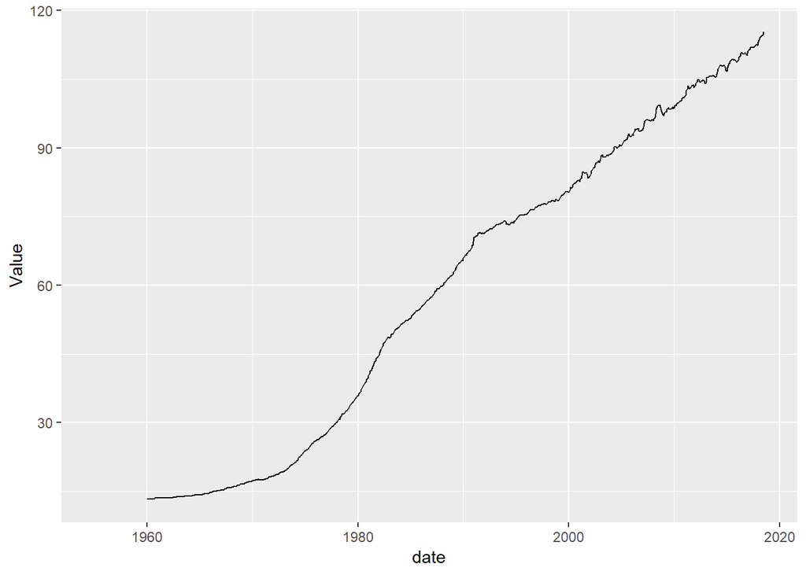

```r
## Import Canada file and set to object CAN
CAN <- read_csv("C:/Users/squin/Desktop/Blog/Data/consumer-price-index-of-all-items-in-canada.csv") %>%
    mutate(Value = as.double(value))
## Parsed with column specification:
## cols(
##   realtime_end = col_date(format = ""),
##   value = col_character(),
##   realtime_start = col_date(format = ""),
##   date = col_date(format = "")
## )
## Warning in evalq(as.double(value), <environment>): NAs introduced by
## coercion
## Plot data to verify
ggplot(CAN, aes(date, Value)) + geom_line()
```

Whilst both these techniques are fine, if we’re working with multiple files it’s probably better to load them in en masse. We can use list.files and lapply to condense the data into a single dataframe. Within the same piped function, we’ll mutate in the nested file data, unnest it, clean and remove unwanted columns

```r
# change set current wd and change wd to our file source.  This is only required if the files are in another directory to your working.
path <- "C:/Users/squin/Desktop/Blog/Data"
setwd(path)

# Regex codes required for string matching. \\ escapes the match string as "." is a special character.  $ denotes the end of string.
imp <- list.files(pattern = "\\.csv$")
imp
```

```
## [1] "consumer-price-index-all-items-for-new-zealand.csv"
## [2] "consumer-price-index-all-items-for-the-united-states.csv"
## [3] "consumer-price-index-of-all-items-in-australia.csv"
## [4] "consumer-price-index-of-all-items-in-canada.csv"
```

```r
# Read in CSV files whilst retaining the file names (for row identification), clean up
df <- tibble(File = imp) %>%
    mutate(Data = lapply(File, read_csv)) %>%
    unnest(Data) %>%
    mutate(Value = as.double(value)) %>%
    select(-realtime_end, -realtime_start, -value)
## Parsed with column specification:
## cols(
##   realtime_end = col_date(format = ""),
##   value = col_character(),
##   realtime_start = col_date(format = ""),
##   date = col_date(format = "")
## )
## Parsed with column specification:
## cols(
##   realtime_end = col_date(format = ""),
##   value = col_character(),
##   realtime_start = col_date(format = ""),
##   date = col_date(format = "")
## )
## Parsed with column specification:
## cols(
##   realtime_end = col_date(format = ""),
##   value = col_character(),
##   realtime_start = col_date(format = ""),
##   date = col_date(format = "")
## )
## Parsed with column specification:
## cols(
##   realtime_end = col_date(format = ""),
##   value = col_character(),
##   realtime_start = col_date(format = ""),
##   date = col_date(format = "")
## )
## Warning in evalq(as.double(value), <environment>): NAs introduced by
## coercion

head(df)
```

```
## # A tibble: 6 x 3
##   File                                               date       Value
##   <chr>                                              <date>     <dbl>
## 1 consumer-price-index-all-items-for-new-zealand.csv 1955-01-01    NA
## 2 consumer-price-index-all-items-for-new-zealand.csv 1955-04-01    NA
## 3 consumer-price-index-all-items-for-new-zealand.csv 1955-07-01    NA
## 4 consumer-price-index-all-items-for-new-zealand.csv 1955-10-01    NA
## 5 consumer-price-index-all-items-for-new-zealand.csv 1956-01-01    NA
## 6 consumer-price-index-all-items-for-new-zealand.csv 1956-04-01    NA
```

This is a good start, but let’s make it a bit more readable by replacing the filename with a country shorthand.

```r
df <- df %>%
  mutate(Country =  c("NZ", "USA", "AUS", "CAN") [grepl("new-zealand", File)+2*grepl("united-states", File)+3*grepl("australia", File)+4*grepl("canada", File)])

df
```

```
## # A tibble: 2,034 x 4
##    File                                           date       Value Country
##    <chr>                                          <date>     <dbl> <chr>
##  1 consumer-price-index-all-items-for-new-zealan~ 1955-01-01    NA NZ
##  2 consumer-price-index-all-items-for-new-zealan~ 1955-04-01    NA NZ
##  3 consumer-price-index-all-items-for-new-zealan~ 1955-07-01    NA NZ
##  4 consumer-price-index-all-items-for-new-zealan~ 1955-10-01    NA NZ
##  5 consumer-price-index-all-items-for-new-zealan~ 1956-01-01    NA NZ
##  6 consumer-price-index-all-items-for-new-zealan~ 1956-04-01    NA NZ
##  7 consumer-price-index-all-items-for-new-zealan~ 1956-07-01    NA NZ
##  8 consumer-price-index-all-items-for-new-zealan~ 1956-10-01    NA NZ
##  9 consumer-price-index-all-items-for-new-zealan~ 1957-01-01    NA NZ
## 10 consumer-price-index-all-items-for-new-zealan~ 1957-04-01    NA NZ
## # ... with 2,024 more rows
```

Great! Let’s plot it.

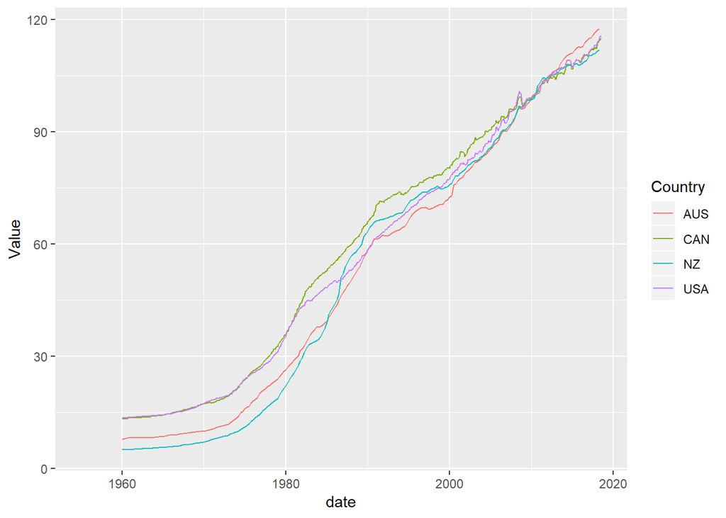

```r
ggplot(df, aes(x = date, y = Value, colour = Country)) + geom_line()
```

We now have a dataset ready to go. Next post we’ll do some analysis on the full data set and see what sort of insights we can gain.